# Neural Network with [http://scikit-learn.org/](https://scikit-learn.org/stable/modules/neural_networks_supervised.html)

## Classification with Neural Network

- **Klasyfikacja z regresją liniową**

```
[Parallel(n_jobs=1)]: Using backend SequentialBackend with 1 concurrent workers.
```

```
max_iter reached after 20 seconds
Confusion_matrix:
[[767   8  11  49   9   0 144   0  12   0]
 [  3 955   5  26   5   0   4   0   2   0]
 [ 15   6 692   7 161   1 104   0  14   0]
 [ 21  19  13 843  47   1  49   0   7   0]
 [  0   1  73  27 804   1  86   0   8   0]
 [  0   1   0   0   0 902   0  51   5  41]
 [102   1  92  30 128   0 622   0  25   0]
 [  0   0   0   0   0  34   0 934   0  32]
 [  5   1   5  10   4   4  21   6 944   0]
 [  0   0   0   0   0  12   1  33   0 954]]
```

```
[Parallel(n_jobs=1)]: Done   1 out of   1 | elapsed:   19.4s finished
```

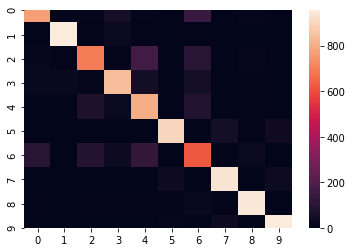

```python
# Import danych
from keras.datasets import fashion_mnist

# Metryki poprawności
from sklearn.metrics import accuracy_score
from sklearn.metrics import confusion_matrix

# Regresja logistyczna
from sklearn.linear_model import LogisticRegression

# Seaborn is a library for making statistical graphics in Python
import seaborn as sns

# Podział na trenujące i testujące
(x_train, y_train), (x_test, y_test) = fashion_mnist.load_data()

# Krok 1 - utworzenie zbioru trenującego
images_train =  []
for image_train in x_train:
    images_train.append(image_train.flatten())

# Krok 2 - utworzenie zbioru testującego
images_test = []
for image_test in x_test:
    images_test.append(image_test.flatten())

# Krok 3 - utworzenie tablic
images_train = np.array(images_train)
images_test = np.array(images_test)

# Krok 4 - utworzenie modelu regresji logistycznej
linear_model = LogisticRegression(verbose=1, max_iter=10, multi_class="multinomial", solver="sag")

# Krok 5 - uczenie modelu
linear_model.fit(images_train, y_train)

# Krok 6 - utworzenie macierzy konfuzji
conf_matrix = confusion_matrix(y_test, linear_model.predict(images_test))

# Wizualizacja wyników
print("Confusion_matrix:")
print(conf_matrix)
sns.heatmap(conf_matrix)
```

```python
# Wyświetlenie wyniku trafności modelu
acc = accuracy_score(y_test, linear_model.predict(images_test))
print("Linear model accuracy is {0:0.2f}".format(acc))
```

```
Linear model accuracy is 0.84
```

- **Classification with Neural Network (MLP) using [MLPClassifier()](https://scikit-learn.org/stable/modules/generated/sklearn.neural_network.MLPClassifier.html)**

```
Confusion_matrix:
[[838   0  11  22   5   1 112   0  11   0]
 [  7 970   1  14   3   0   4   0   1   0]
 [ 25   0 827  10  57   1  76   0   4   0]
 [ 30   5  15 876  28   1  38   0   7   0]
 [  6   0 116  30 759   0  83   0   5   1]
 [  1   1   0   0   1 963   0  15   4  15]
 [131   0  83  25  52   0 688   0  21   0]
 [  0   0   0   0   0  15   0 957   0  28]
 [  4   0   4   4   3   4   5   3 973   0]
 [  0   0   0   0   0  12   1  29   0 958]]
Neural network model accuracy is 0.88
```

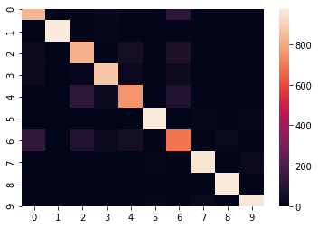

```python
from sklearn.neural_network import MLPClassifier

# Import danych
from keras.datasets import fashion_mnist

# Metryki poprawności
from sklearn.metrics import accuracy_score
from sklearn.metrics import confusion_matrix

# Regresja logistyczna
from sklearn.linear_model import LogisticRegression

# Seaborn is a library for making statistical graphics in Python
import seaborn as sns

# Podział na trenujące i testujące
(x_train, y_train), (x_test, y_test) = fashion_mnist.load_data()

# Krok 1 - utworzenie zbioru trenującego
images_train =  []
for image_train in x_train:
    images_train.append(image_train.flatten())

# Krok 2 - utworzenie zbioru testującego
images_test = []
for image_test in x_test:
    images_test.append(image_test.flatten())

# Krok 3 - utworzenie tablic
images_train = np.array(images_train)
images_test = np.array(images_test)

# Utworzenie sieci neuronowej
neural_network = MLPClassifier(hidden_layer_sizes=(100,50,25),activation ='relu', random_state=1)

# Standaryzacja i nauka modelu
neural_network.fit(preprocessing.StandardScaler().fit_transform(images_train), y_train)

# Utworzenie macierzy konfuzji
conf_matrix_neural_network = confusion_matrix(y_test, \
                                              neural_network.predict(preprocessing.StandardScaler().fit_transform(images_test)))
# Wizualizacja wyników
print("Confusion_matrix:")
print(conf_matrix_neural_network)
sns.heatmap(conf_matrix_neural_network)

# Wyświetlenie wyniku trafności modelu
acc = accuracy_score(y_test, neural_network.predict(preprocessing.StandardScaler().fit_transform(images_test)))
print("Neural network model accuracy is {0:0.2f}".format(acc))
```

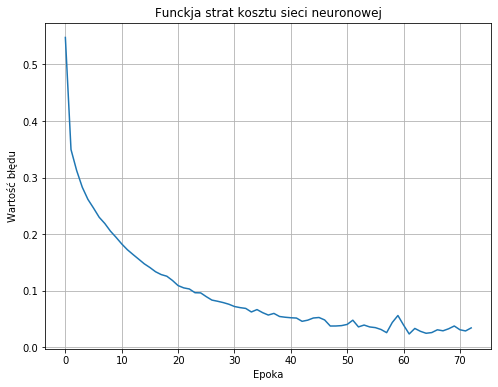

```python
import matplotlib.pyplot as plt
plt.rcParams['figure.figsize'] = (8.0, 6.0)
plt.plot(neural_network.loss_curve_)
plt.title('Funckja strat kosztu sieci neuronowej')
plt.xlabel('Epoka'); plt.ylabel('Wartość błędu'); plt.grid();
```

```python
print("Number of connection between input and first hidden layer:")
print(np.size(neural_network.coefs_[0]))

print("Number of connection between first and second hidden layer:")
print(np.size(neural_network.coefs_[1]))
```

```
Number of connection between input and first hidden layer:
78400
Number of connection between first and second hidden layer:
5000
```

- Visualizing weights in neural network

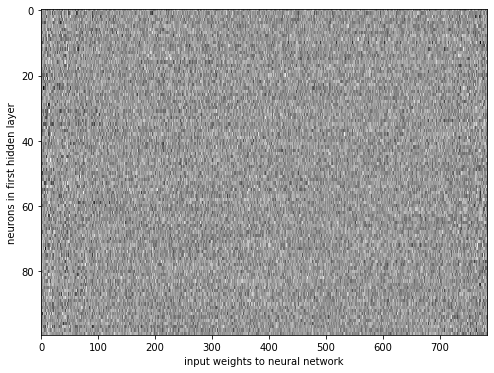

```python
plt.rcParams['figure.figsize'] = (8.0, 6.0)
plt.imshow(np.transpose(neural_network.coefs_[0]), cmap=plt.get_cmap("gray"), aspect="auto")
plt.ylabel('neurons in first hidden layer'); plt.xlabel('input weights to neural network');
```

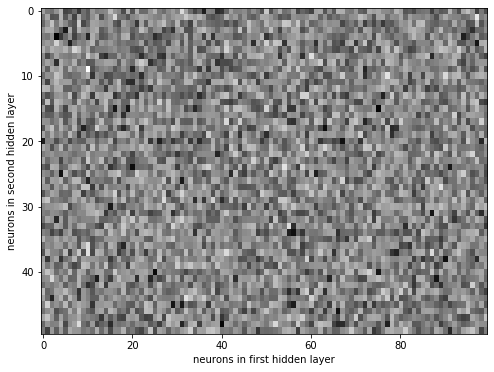

```python
plt.rcParams['figure.figsize'] = (8.0, 6.0)
plt.imshow(np.transpose(neural_network.coefs_[1]), cmap=plt.get_cmap("gray"), aspect="auto")
plt.ylabel('neurons in second hidden layer'); plt.xlabel('neurons in first hidden layer');
```

[figure not shown]

```python
plt.rcParams['figure.figsize'] = [10, 60]
m=100
for i in range(0,m):
    plt.subplot(m/2, 20, i+1)
    plt.axis('off')
    hidden_2 = np.transpose(neural_network.coefs_[0])[i]
    plt.imshow(np.reshape(hidden_2, (28,28)), cmap=plt.get_cmap("gray"),  aspect=1)
```

### ToDo:

1. Learn about [MLPClassifier()](https://scikit-learn.org/stable/modules/generated/sklearn.neural_network.MLPClassifier.html) class and try find better network architecture (using learning parameters and layers) that will have higher accuracy than 0.89 on training data. (smart way would be to use [GridSearch](https://scikit-learn.org/stable/modules/generated/sklearn.model_selection.GridSearchCV.html))
1. Train Feed-Forward neural network to recognize hand written digits using Mnist dataset. Visualize learning process and weights connected to the first layer.

```
Confusion_matrix:
[[838   3   7  19   3   0 122   0   8   0]
 [  5 979   1   5   6   0   3   0   1   0]
 [ 23   0 850   9  57   0  61   0   0   0]
 [ 19  11  11 900  29   1  25   0   4   0]
 [  0   0 117  26 808   1  46   0   2   0]
 [  0   0   1   0   0 947   0  26   1  25]
 [118   1  82  27  68   1 694   0   9   0]
 [  0   0   0   0   0   4   0 978   0  18]
 [  3   0   2   8   4   7   5   5 965   1]
 [  0   0   0   0   0   4   1  36   0 959]]
Neural network model accuracy is 0.89
```

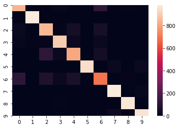

```python
from sklearn.neural_network import MLPClassifier

# Import danych
from keras.datasets import fashion_mnist

# Metryki poprawności
from sklearn.metrics import accuracy_score
from sklearn.metrics import confusion_matrix

# Regresja logistyczna
from sklearn.linear_model import LogisticRegression

# Seaborn is a library for making statistical graphics in Python
import seaborn as sns

# Podział na trenujące i testujące
(x_train, y_train), (x_test, y_test) = fashion_mnist.load_data()

# Krok 1 - utworzenie zbioru trenującego
images_train =  []
for image_train in x_train:
    images_train.append(image_train.flatten())

# Krok 2 - utworzenie zbioru testującego
images_test = []
for image_test in x_test:
    images_test.append(image_test.flatten())

# Krok 3 - utworzenie tablic
images_train = np.array(images_train)
images_test = np.array(images_test)

# Utworzenie sieci neuronowej
siec = MLPClassifier(hidden_layer_sizes=(250,300,100),activation ='relu', random_state=1)

# Standaryzacja i nauka modelu
siec.fit(preprocessing.StandardScaler().fit_transform(images_train), y_train)

# Utworzenie macierzy konfuzji
conf_matrix_neural_network = confusion_matrix(y_test, \
                                              siec.predict(preprocessing.StandardScaler().fit_transform(images_test)))
# Wizualizacja wyników
print("Confusion_matrix:")
print(conf_matrix_neural_network)
sns.heatmap(conf_matrix_neural_network)

# Wyświetlenie wyniku trafności modelu
acc = accuracy_score(y_test, siec.predict(preprocessing.StandardScaler().fit_transform(images_test)))
print("Neural network model accuracy is {0:0.2f}".format(acc))
```

```
Confusion_matrix:
[[792   5  24  91  10   4  64   0  10   0]
 [ 10 931   5  46   2   0   5   0   1   0]
 [ 32   0 672  11 176   0 102   0   7   0]
 [ 53  21   7 825  40   0  49   0   5   0]
 [  1   0 170  50 709   0  56   0  14   0]
 [  0   0   0   0   0 881   1  67   9  42]
 [216   0 262  65 229   3 210   0  15   0]
 [  0   0   0   0   0  51   0 897   0  52]
 [  0   0  13   7  19  23  14   3 918   3]
 [  0   0   0   0   0  20   1  63   2 914]]
Neural network model accuracy is 0.77
```

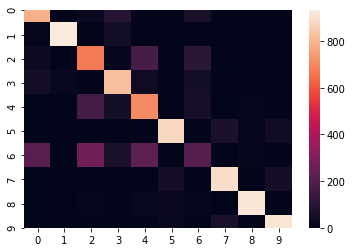

```python
from sklearn.neural_network import MLPClassifier

# Import danych
from keras.datasets import fashion_mnist

# Metryki poprawności
from sklearn.metrics import accuracy_score
from sklearn.metrics import confusion_matrix

# Regresja logistyczna
from sklearn.linear_model import LogisticRegression

# Seaborn is a library for making statistical graphics in Python
import seaborn as sns

# Podział na trenujące i testujące
(x_train, y_train), (x_test, y_test) = fashion_mnist.load_data()

# Krok 1 - utworzenie zbioru trenującego
images_train =  []
for image_train in x_train:
    images_train.append(image_train.flatten())

# Krok 2 - utworzenie zbioru testującego
images_test = []
for image_test in x_test:
    images_test.append(image_test.flatten())

# Krok 3 - utworzenie tablic
images_train = np.array(images_train)
images_test = np.array(images_test)

# Utworzenie sieci neuronowej
siec = MLPClassifier(hidden_layer_sizes=(250,300,100),activation ='logistic', solver="sgd", random_state=1)

# Standaryzacja i nauka modelu
siec.fit(preprocessing.StandardScaler().fit_transform(images_train), y_train)

# Utworzenie macierzy konfuzji
conf_matrix_neural_network = confusion_matrix(y_test, \
                                              siec.predict(preprocessing.StandardScaler().fit_transform(images_test)))
# Wizualizacja wyników
print("Confusion_matrix:")
print(conf_matrix_neural_network)
sns.heatmap(conf_matrix_neural_network)

# Wyświetlenie wyniku trafności modelu
acc = accuracy_score(y_test, siec.predict(preprocessing.StandardScaler().fit_transform(images_test)))
print("Neural network model accuracy is {0:0.2f}".format(acc))
```

```python
# 2. Train Feed-Forward neural network to recognize hand written digits
#    using Mnist dataset. Visualize learning process and weights connected to the first layer.
```

```
Datasets size
Train data: (60000, 28, 28)
Test data: (10000, 28, 28)
Samples from training data:
```

```
MLPClassifier(activation='relu', alpha=0.0001, batch_size='auto', beta_1=0.9,
              beta_2=0.999, early_stopping=False, epsilon=1e-08,
              hidden_layer_sizes=(250, 300, 100), learning_rate='constant',
              learning_rate_init=0.001, max_iter=200, momentum=0.9,
              n_iter_no_change=10, nesterovs_momentum=True, power_t=0.5,
              random_state=1, shuffle=True, solver='adam', tol=0.0001,
              validation_fraction=0.1, verbose=False, warm_start=False)
```

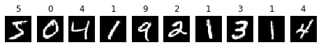

```python
import keras
from keras.datasets import mnist
import matplotlib.pyplot as plt
import numpy as np
from sklearn.neural_network import MLPClassifier
from sklearn import preprocessing

# Metryki poprawności
from sklearn.metrics import accuracy_score
from sklearn.metrics import confusion_matrix

#load mnist dataset
(X_train, y_train), (X_test, y_test) = mnist.load_data()

print("Datasets size")
print("Train data:", X_train.shape)
print("Test data:", X_test.shape)

print("Samples from training data:")
for i in range(0,10):
    plt.subplot(1,10,i+1)
    plt.imshow(X_train[i], cmap=plt.get_cmap("gray"))
    plt.title(y_train[i]);
    plt.axis('off');

# Krok 1 - utworzenie zbioru trenującego
images_train =  []
for image_train in X_train:
    images_train.append(image_train.flatten())

# Krok 2 - utworzenie zbioru testującego
images_test = []
for image_test in X_test:
    images_test.append(image_test.flatten())

# Krok 3 - utworzenie tablic
images_train = np.array(images_train)
images_test = np.array(images_test)

# Utworzenie sieci neuronowej
siec = MLPClassifier(hidden_layer_sizes=(250,300,100),activation ='relu', random_state=1)

# Standaryzacja i nauka modelu
siec.fit(preprocessing.StandardScaler().fit_transform(images_train), y_train)
```

```python
# Wyświetlenie wyniku trafności modelu
acc = accuracy_score(y_test, siec.predict(preprocessing.StandardScaler().fit_transform(images_test)))
print("Neural network model accuracy is {0:0.2f}".format(acc))
```

```
Neural network model accuracy is 0.98
```

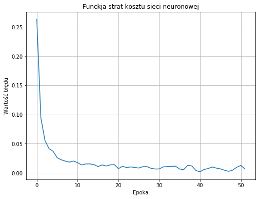

```python
# Wizualizacja
plt.plot(siec.loss_curve_)
plt.title('Funckja strat kosztu sieci neuronowej')
plt.xlabel('Epoka'); plt.ylabel('Wartość błędu'); plt.grid();
```

```python
print("Number of connection between input and first hidden layer:")
print(np.size(siec.coefs_[0]))

print("Number of connection between first and second hidden layer:")
print(np.size(siec.coefs_[1]))
```

```
Number of connection between input and first hidden layer:
196000
Number of connection between first and second hidden layer:
75000
```

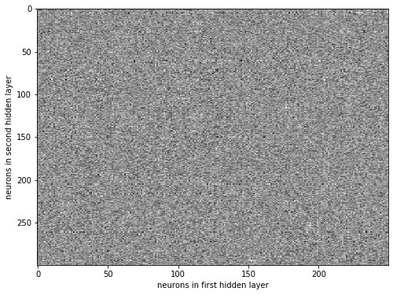

```python
plt.rcParams['figure.figsize'] = (8.0, 6.0)
plt.imshow(np.transpose(siec.coefs_[1]), cmap=plt.get_cmap("gray"), aspect="auto")
plt.ylabel('neurons in second hidden layer'); plt.xlabel('neurons in first hidden layer');
```